# Temporal patterns

Abhijit Dasgupta, PhD

6/19/2020

# Introduction

The openFDA API is a means to access information about adverse events reported to the FDA from 2004 onwards. In this paper, we use the online API and the R package `openfda` to investigate temporal patterns in adverse events reporting. The primary interest is in characterizing who is reporting adverse events, given that reporting adverse events to the FDA is voluntary.

# Qualifications of the reporter

The reporters can be in one of 5 categories:

```
## [1] "Physician"                           "Consumer or non-health professional"
## [3] "Other health professional"           "Pharmacist"
## [5] "Lawyer"
```

The following graph looks at the proportion of adverse events by reporters of each cateogory in each year from 2004 onwards. (Due to limitations in the number of allowed API calls, I am presenting an earlier figure, and also providing the code).

[figure not shown]

```r
yrs <- seq(2004:2020)
freq_quals_world <- map(yrs,
                  ~fda_query('/drug/event.json') %>%
                    fda_filter('receivedate', paste0('[', .x, '0101+TO+',.x,'1231]')) %>%
                    fda_count('primarysource.qualification') %>%
                    fda_limit(1000) %>% fda_exec() %>% set_names(c('term',paste('count', .x, sep='_'))))
freq_quals_world <- reduce(freq_quals_world, full_join) %>%
  gather(yr, counts, -term) %>%
  mutate(yr = as.numeric(str_remove(yr, 'count_')))
quals_key = tribble(~code,~qualification,
                    1, 'Physician',
                    2, 'Pharmacist',
                    3, 'Other health professional',
                    4, 'Lawyer',
                    5, 'Consumer or non-health professional')
freq_quals_world <- freq_quals_world %>% left_join(quals_key, by=c('term'='code'))

freq_quals_world %>% group_by(yr) %>%
  mutate(perc = counts/sum(counts, na.rm=T)*100) %>%
  ungroup() %>%
  ggplot(aes(x = yr, y = counts, fill = qualification)) +
  geom_bar(stat='identity', position='fill') +
  scale_y_continuous(labels = scales::percent_format())+
  labs(x = 'Year', y = 'Percent', title = 'Who reports (USA)', caption='Source: openfda.gov') +
  theme_classic()
```

It is clear that worldwide, a greater proportion of advverse events are reported by consumers and non-health professionals, while the proportion reported by physicians shows a steady decline. For the US, on the other hand, the relative proportions have been relatively steady, though the proportion of AE reported by physicians is declining, as seen below. It is also gratifying to see that the role of lawyers in reporting adverse events has decreased over time.

[figure not shown]

```r
freq_quals <- map(yrs,
                        ~fda_query('/drug/event.json') %>%
                          fda_filter('receivedate', paste0('[', .x, '0101+TO+',.x,'1231]')) %>%
                          fda_filter('primarysource.reportercountry.exact','US') %>%
                          fda_count('primarysource.qualification') %>%
                          fda_limit(1000) %>% fda_exec() %>% set_names(c('term',paste('count', .x, sep='_'))))
freq_quals <- reduce(freq_quals, full_join) %>%
  gather(yr, counts, -term) %>%
  mutate(yr = as.numeric(str_remove(yr, 'count_')))
quals_key = tribble(~code,~qualification,
                    1, 'Physician',
                    2, 'Pharmacist',
                    3, 'Other health professional',
                    4, 'Lawyer',
                    5, 'Consumer or non-health professional')
freq_quals <- freq_quals %>% left_join(quals_key, by=c('term'='code'))

freq_quals %>% group_by(yr) %>%
  mutate(perc = counts/sum(counts, na.rm=T)*100) %>%
  ungroup() %>%
  ggplot(aes(x = yr, y = counts, fill = qualification)) +
    geom_bar(stat='identity', position='fill') +
    scale_y_continuous(labels = scales::percent_format())+
  labs(x = 'Year', y = 'Percent', title = 'Who reports (World)', caption='Source: openfda.gov') +
  theme_classic()
```

# Countries

The US remains the largerst reported of adverse events to the FDA, though other countries do report in large numbers as well. Here we compare the numbers of reported adverse events among the top 10 countries in reporting AE in 2019.

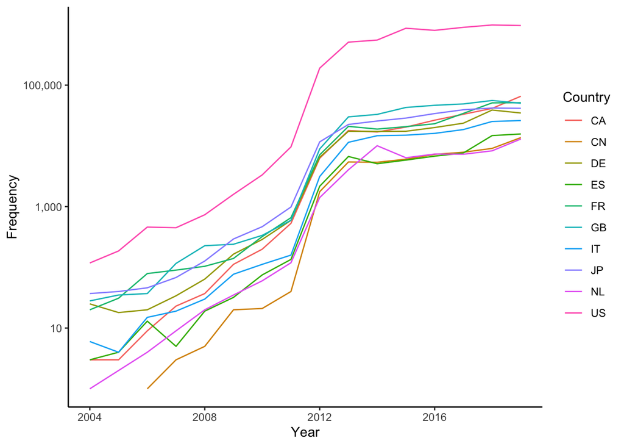

```r
# freq_country <- map(yrs, ~fda_query('/drug/event.json') %>%
#       fda_filter('receivedate',paste0('[',.x,'0101+TO+',.x,'1231]')) %>%
#       fda_count('primarysource.reportercountry.exact') %>%
#       fda_limit(1000) %>% fda_exec() %>% set_names(c('term', paste('count',.x, sep='_'))))
bl = reduce(freq_country, right_join) %>%
  gather(year, count,-term) %>%
  mutate(year = as.numeric(str_remove(year, 'count_'))) %>%
  mutate(term = ifelse(term=='COUNTRY NOT SPECIFIED', NA, term))

top_10 <- bl %>% filter(year==2019, !is.na(term)) %>% slice_max(count, n=10)

ggplot(bl %>% filter(year < 2020, !is.na(term), term %in% top_10$term), aes(x = year, y=count, color=term))+
  geom_line(show.legend=T) + scale_y_log10('Frequency', labels = scales::comma_format()) +
  labs(x='Year', color='Country') + theme_classic()
```

On the log-scale, all the countries show a similar temporal pattern, with several countries contributing 10s of thousands of reports each year. We will note here that the number of countries contributing to FAERS has increased from 17 in 2004 to 149 in 2020.

# Indicators

The health indicators with the highest frequency of AE reports has changed over time. We look at the top 10 indicators in terms of frequency of AE reports for each year. The following table shows this set of indicators and the years they made the top 10.

```r
# freq_indications <- map(yrs,
#                         ~fda_query('/drug/event.json') %>%
#                           fda_filter('receivedate', paste0('[', .x, '0101+TO+',.x,'1231]')) %>%
#                           fda_count('patient.drug.drugindication.exact') %>%
#                           fda_limit(1000) %>% fda_exec() %>% set_names(c('term',paste('count', .x, sep='_'))))
# freq_indications = reduce(freq_indications, full_join) %>%
#   gather(yr, count, -term) %>%
#   mutate(yr = as.numeric(str_remove(yr, 'count_')))
freq_indications %>% nest(-yr, data=c(term,count)) %>%
  mutate(data = map(data, slice_max, count, n=10)) %>%
  unnest() %>% select(-count) %>%
  janitor::tabyl(term, yr) %>%
  janitor::adorn_totals('col') %>%
  arrange(-Total)
```

```
##                                      term 2004 2005 2006 2007 2008 2009 2010
##                              HYPERTENSION    1    1    1    1    1    1    1
##                        MULTIPLE SCLEROSIS    1    1    1    1    1    1    1
##                      RHEUMATOID ARTHRITIS    1    1    1    1    1    1    1
##                                      PAIN    1    1    1    1    1    1    1
##                                 PSORIASIS    0    0    0    0    1    1    0
##       PRODUCT USED FOR UNKNOWN INDICATION    0    0    0    0    0    0    1
##                                DEPRESSION    1    1    1    1    1    1    1
##                         DIABETES MELLITUS    0    0    0    1    0    1    1
##                  TYPE 2 DIABETES MELLITUS    0    0    0    1    1    0    0
##                             CONTRACEPTION    1    0    0    0    1    1    0
##           DRUG USE FOR UNKNOWN INDICATION    1    1    1    1    1    1    1
##                       PLASMA CELL MYELOMA    0    0    0    0    0    0    0
##                              OSTEOPOROSIS    1    1    0    1    1    0    0
##                     PSORIATIC ARTHROPATHY    0    0    0    0    0    0    0
##                           CROHN^S DISEASE    0    0    0    0    0    0    0
##                      ILL-DEFINED DISORDER    1    1    1    0    0    0    0
##                                      ACNE    0    0    0    0    0    0    0
##                                 ARTHRITIS    0    1    1    0    0    0    0
##                       ATRIAL FIBRILLATION    0    0    0    0    0    0    0
##                           CROHN'S DISEASE    0    0    0    0    0    1    0
##   DIABETES MELLITUS NON-INSULIN-DEPENDENT    0    0    1    1    0    0    0
##                       PERITONEAL DIALYSIS    0    0    0    0    0    0    0
##                                    ASTHMA    0    1    0    0    0    0    0
##  ATTENTION DEFICIT/HYPERACTIVITY DISORDER    1    0    0    0    0    0    0
##               BLOOD CHOLESTEROL INCREASED    0    0    0    0    0    0    1
##                               HEPATITIS C    0    0    0    0    0    0    0
##                                  INSOMNIA    0    0    1    0    0    0    0
##                 SMOKING CESSATION THERAPY    0    0    0    0    0    0    1
##  2011 2012 2013 2014 2015 2016 2017 2018 2019 2020 Total
##     1    1    1    1    1    1    1    1    1    1    17
##     1    1    1    1    1    1    1    1    1    1    17
##     1    1    1    1    1    1    1    1    1    1    17
##     1    1    1    1    1    1    1    1    1    0    16
##     1    1    1    1    1    1    1    1    1    1    12
##     1    1    1    1    1    1    1    1    1    1    11
##     1    1    0    0    0    0    0    0    0    0     9
##     1    1    1    1    1    0    0    0    0    0     8
##     0    0    0    0    1    1    1    1    1    1     8
##     1    1    1    1    0    0    0    0    0    0     7
##     0    0    0    0    0    0    0    0    0    0     7
##     0    0    0    0    1    1    1    1    1    1     6
##     0    0    0    0    1    0    0    0    0    0     5
##     0    0    0    0    0    1    1    1    1    1     5
##     0    0    1    1    0    1    0    0    0    1     4
##     0    0    0    0    0    0    0    0    0    0     3
##     0    0    0    0    0    0    0    0    1    1     2
##     0    0    0    0    0    0    0    0    0    0     2
##     0    0    0    0    0    0    1    1    0    0     2
##     1    0    0    0    0    0    0    0    0    0     2
##     0    0    0    0    0    0    0    0    0    0     2
##     0    0    1    1    0    0    0    0    0    0     2
##     0    0    0    0    0    0    0    0    0    0     1
##     0    0    0    0    0    0    0    0    0    0     1
##     0    0    0    0    0    0    0    0    0    0     1
##     0    1    0    0    0    0    0    0    0    0     1
##     0    0    0    0    0    0    0    0    0    0     1
##     0    0    0    0    0    0    0    0    0    0     1
```

This table shows some interesting patterns. First, hypertension, MS and rheumatoid arthritis have been in the top 10 highest reported adverse events all 17 years, and pain fell off just in 2020, for which we have partial data. Depression and contraception have fallen off the top 10 list in recent years, indicating, perhaps, medicines better suited to user’s needs.

# Seriousness of adverse events

The following figure shows the proportion of adverse events that were deemed serious.

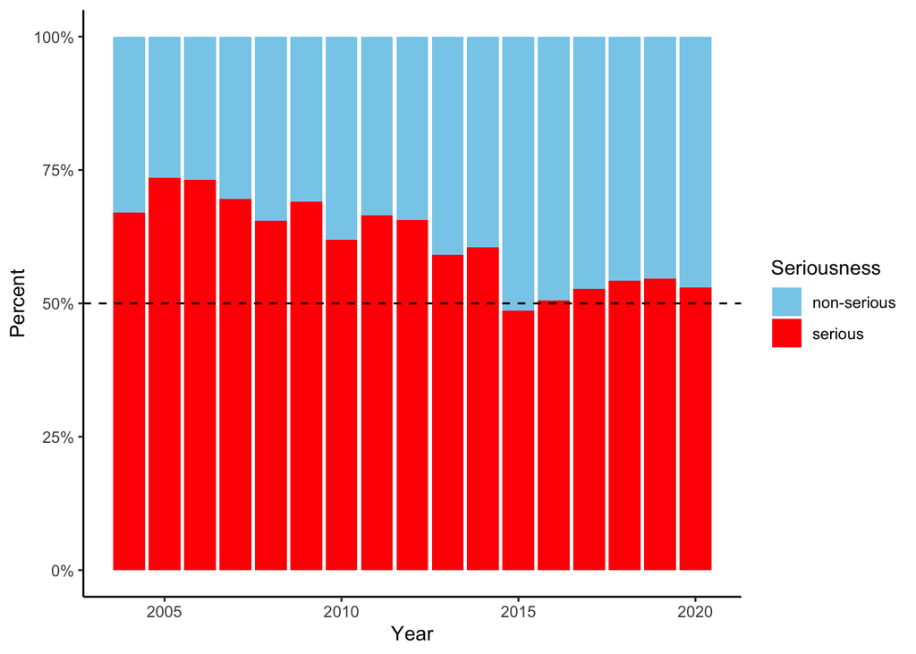

```r
# freq_serious <- map(yrs,
#                     ~fda_query('/drug/event.json') %>%
#                       fda_filter('receivedate', paste0('[', .x, '0101+TO+',.x,'1231]')) %>%
#                       fda_count('serious') %>%
#                       fda_limit(1000) %>% fda_exec() %>% set_names(c('term',paste('count', .x, sep='_'))))
#
# freq_serious <- reduce(freq_serious, full_join) %>%
#   gather(yr, counts, -term) %>%
#   mutate(yr = as.numeric(str_remove(yr, 'count_')))

freq_serious <- freq_serious %>%
  mutate(term = ifelse(term==1, 'serious','non-serious'))
ggplot(freq_serious, aes(x = yr, y = count, fill = as.factor(term)))+
  geom_bar(stat='identity', position='fill') +
  geom_hline(yintercept = 0.5, linetype=2)+
  scale_x_continuous('Year')+
  scale_y_continuous('Percent', labels = scales::percent_format())+
  scale_fill_manual(values = c('serious'='red', 'non-serious'='skyblue'))+
  theme_classic() +
  labs(fill = 'Seriousness')
```

We see that the reporting of non-serious events has increased significantly over the years, pointing to (a) more awareness of reporting and (b) understanding that non-serious events also should be reported.

# Gender

The following table shows the proportion of reported events by gender.

```r
# freq_gender <- map(yrs,
#                   ~fda_query('/drug/event.json') %>%
#                     fda_filter('receivedate', paste0('[', .x, '0101+TO+',.x,'1231]')) %>%
#                     # fda_filter('patient.drug.drugindication','multiple') %>%
#                     fda_count('patient.patientsex') %>%
#                     fda_limit(1000) %>% fda_exec() %>% set_names(c('term',paste('count', .x, sep='_'))))
#
# freq_gender <- reduce(freq_gender, full_join) %>%
#   gather(yr, counts, -term) %>%
#   mutate(yr = as.numeric(str_remove(yr, 'count_')))

freq_gender %>% filter(term!= '0') %>%
  mutate(term=ifelse(term=='1', 'Male','Female')) %>%
  rename(Gender=term) %>%
  spread(Gender, count) %>%
  rename(Year=yr) %>%
  as_tabyl() %>%
  adorn_percentages() %>%
  adorn_pct_formatting() %>%
  kable()
```

| Year | Female | Male |
| --- | --- | --- |
| 2004 | 60.1% | 39.9% |
| 2005 | 57.8% | 42.2% |
| 2006 | 58.6% | 41.4% |
| 2007 | 60.8% | 39.2% |
| 2008 | 62.0% | 38.0% |
| 2009 | 60.8% | 39.2% |
| 2010 | 61.7% | 38.3% |
| 2011 | 62.8% | 37.2% |
| 2012 | 62.3% | 37.7% |
| 2013 | 62.6% | 37.4% |
| 2014 | 61.9% | 38.1% |
| 2015 | 61.3% | 38.7% |
| 2016 | 60.9% | 39.1% |
| 2017 | 61.2% | 38.8% |
| 2018 | 61.8% | 38.2% |
| 2019 | 61.9% | 38.1% |
| 2020 | 62.0% | 38.0% |

It is evident that a greater proportion of adverse events are reported by women, and this pattern is remarkably consistent over time. We would posit that this is not purely biological but reflective of a greater sensitivity to abnormal reactions and a willlingness to report these abnormalities among women compared to men. We’ll delve more into this when we look deeply at the 2020 data.